# Regression Based Models

Concepts and applications

Christophe Bontemps & Patrick Jonsson - SIAP[^1]

# Introduction

The main focus here is on using a regression model within a Machine Learning problem when we have many regressors. We will be trying to construct a “*good model*”, through variable selection algorithms and regularization techniques.

We will use an example where many regressors, possibly correlated, are used and we will explore methods like Stepwise-regression, Ridge regression and Lasso regression as some tools to construct the “*best*” set of variables. Through *Cross validation* we will also evaluate if the fitted models produces results that generalizes well.

## Regression model

We have a linear regression model
$$y = \beta_0 + x'\beta + \varepsilon \qquad E (\varepsilon|x) = 0
\, ,$$
with possibly **many regressors** in $x$. The intercept is always included in the model.So we have a bunch of regressors, we would like to retain only those helpful in explaining $y$. We have already encountered this issue in the context of polynomial regression.

Selection of regressors is an old problem, so we have many existing solutions. It is part of *feature selection* or *feature elimination* problems. Before detailing statistical learning methods, we will look at “variations” around the linear regression model.

## An Example

- Trans = Nb of transactions in 2020
- HighTrans = Nb of high value transactions in 2020
- Checks = Nb of Checks in 2020
- Dinning = Nb of Dinnings in 2020
- Shopping = Nb of Shopping purchases in 2020
- Gas = Nb of payments at gas stations in 2020
- Years = Nb of years at the bank
- TotalTrans = Nb of transactions since at the bank  
  -TotalHighTrans = Nb of high value transactions since at the bank
- TotalChecks = Nb of Checks since at the bank
- TotalDinning = Nb of Dinnings since at the bank
- TotalShipping = Nb of Shopping purchases since at the bank
- TotalGas = Nb of payments at gas stations since at the bank
- Category = New (N) or Ancient (A) at the agency
- Agency = Name of the Agency (East or West Bd)
- OnlineTrans = Nb of online purchases in 2020 ,
- widthdrawals = Nb of withdrawals
- RejectedTrans = Nb of rejected transactions
- NewCategory = New (N) or Ancient (A) at the agency in 2021
- Salary = Salary in 2020 (thousands of dollars)

## Data Analysis

It is always a good habit to start with some descriptive statistics on all the variables.

```r
# From the library modelsummary we can create a nice summary table
datasummary_skim(BankAccount)
```

Unique

Missing Pct.

Mean

SD

Min

Median

Max

Histogram

Trans

209

0

403.6

147.3

19.0

413.0

687.0

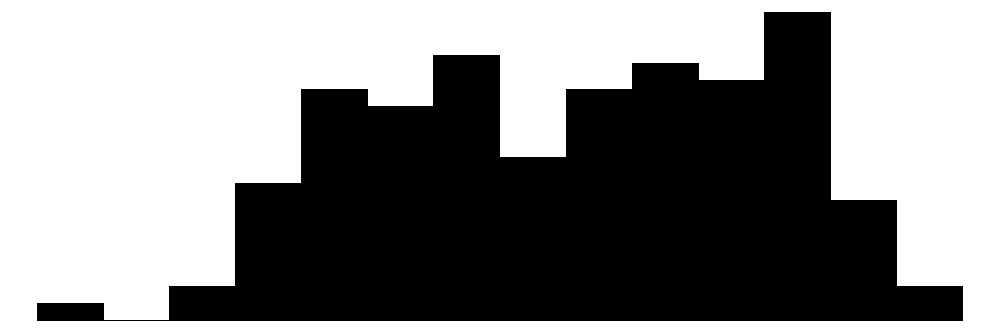

HighTrans

130

0

107.8

45.1

1.0

103.0

238.0

[figure not shown]

Checks

35

0

11.6

8.8

0.0

9.0

40.0

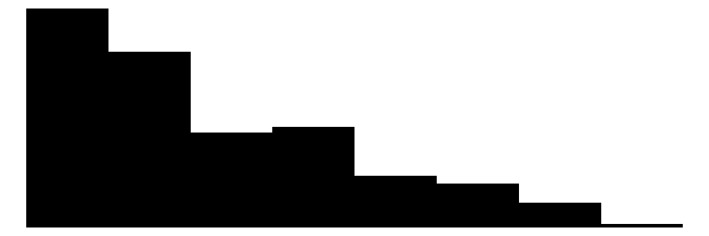

Dinning

92

0

54.7

25.5

0.0

52.0

130.0

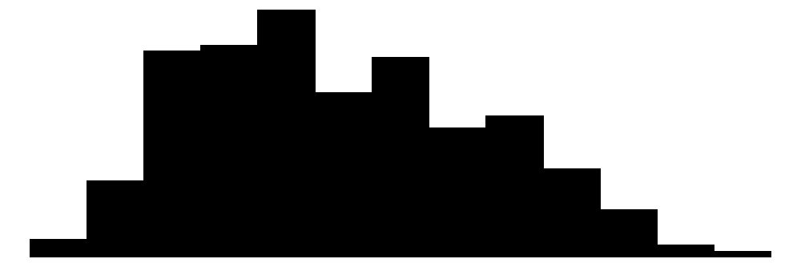

Shopping

94

0

51.5

25.9

0.0

47.0

121.0

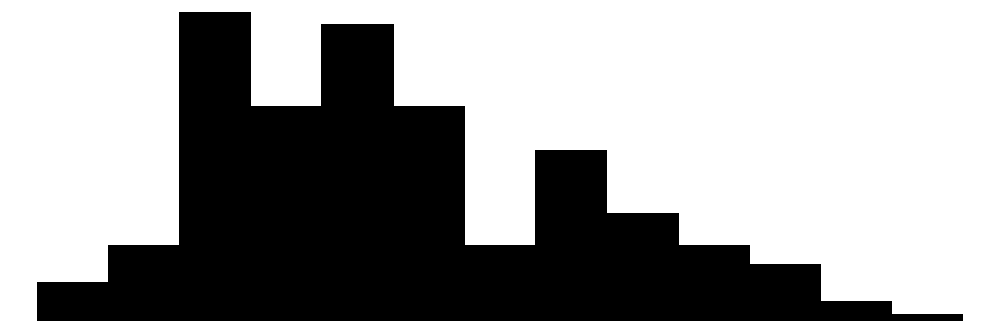

Gas

87

0

41.1

21.7

0.0

37.0

105.0

[figure not shown]

Years

21

0

7.3

4.8

1.0

6.0

24.0

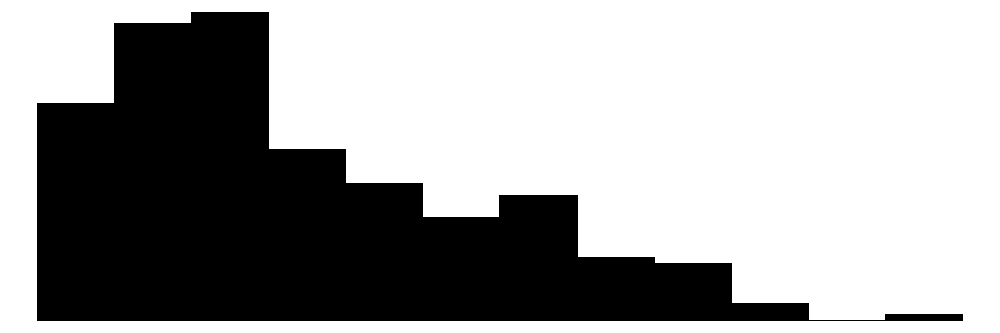

TotalTrans

257

0

2657.5

2286.6

19.0

1931.0

14053.0

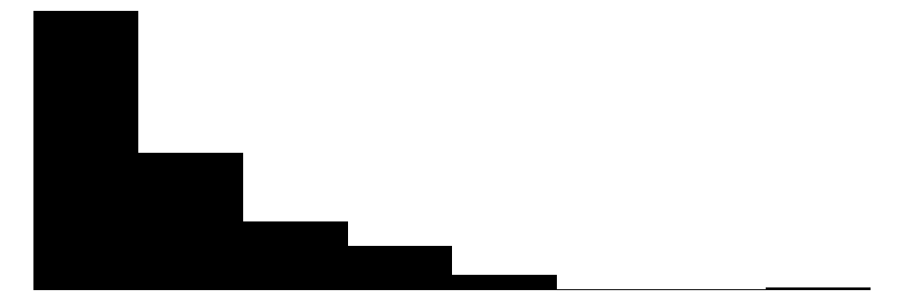

TotalHighTrans

241

0

722.2

648.2

4.0

516.0

4256.0

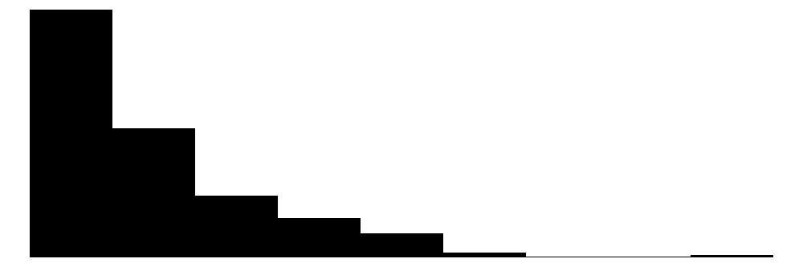

TotalChecks

129

0

69.2

82.2

0.0

40.0

548.0

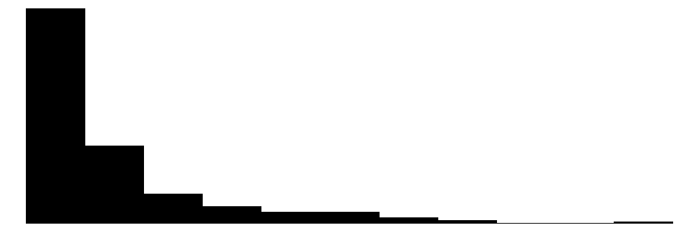

TotalDinning

226

0

361.2

331.2

2.0

250.0

2165.0

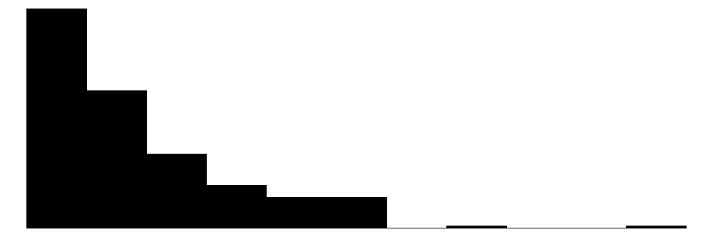

TotalShopping

226

0

330.4

323.4

3.0

230.0

1659.0

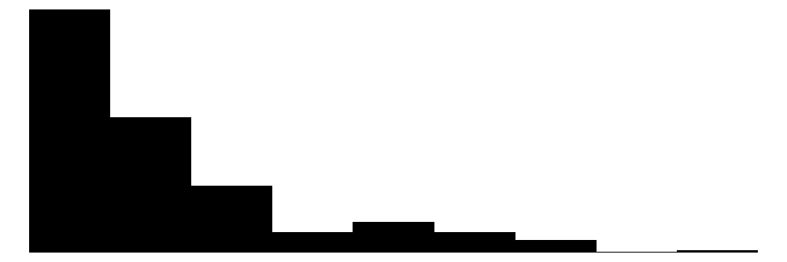

TotalGas

207

0

260.3

264.1

1.0

174.0

1566.0

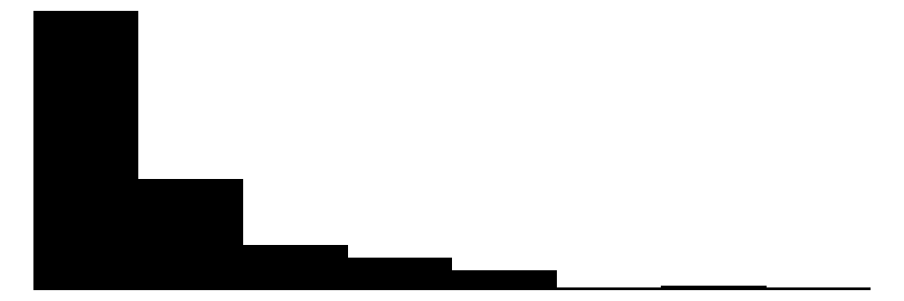

OnlineTrans

199

0

290.7

279.9

0.0

224.0

1377.0

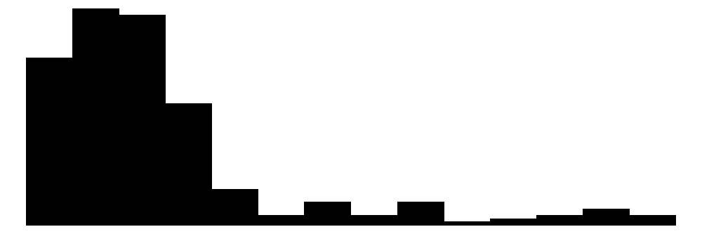

widthdrawals

145

0

118.8

145.1

0.0

45.0

492.0

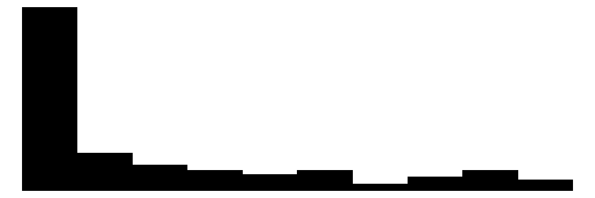

RejectedTrans

29

0

8.6

6.6

0.0

7.0

32.0

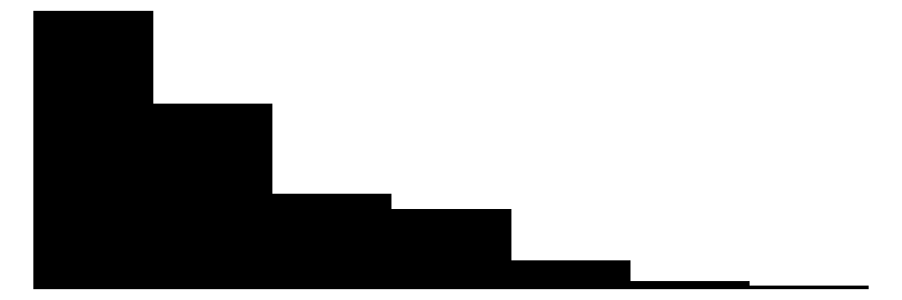

Salary

150

0

5.9

0.9

4.2

6.1

7.8

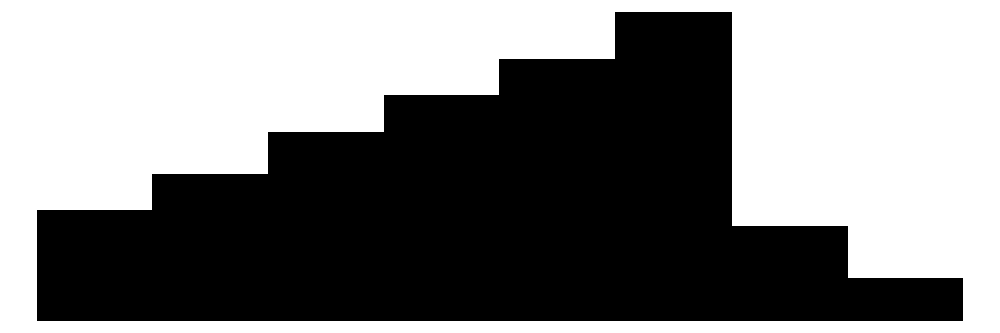

NewCategory

2

0

1.5

0.5

1.0

1.0

2.0

[figure not shown]

N

%

Category

A

139

52.9

N

124

47.1

Agency

E

129

49.0

W

134

51.0

# Linear Regression and All His Friends

The linear regression is one of the most popular tool. Let us recall some characteristics of this model.

$$y = \beta_0 + \beta_1 x_1 + \ldots + \beta_{k} x_k + \varepsilon \qquad
E (\varepsilon|x) = 0
\, .$$
We know that:

- $\beta_j$ is the “*ceteris paribus*” marginal effect of $x_j$ on $y$. That is *when $x_j$ increases by one unit, and no other value change on any other $x$s, then $y$ increase by $\beta_j$ units*.
- $\beta_0$ is the mean of $y$ if all $x_j$ are equal to zero. Since it is rare that we can encounter this situation, we usually don’t interpret this coefficient.

> What is effect of taking the mean on both side of the regression?

$$E(y) = \beta_0 + \beta_1 E(x_1) + \cdots + \beta_{k} E(x_k)
\, .$$
or
$$\beta_0 = E(y) - \beta_1 E(x_1) - \ldots - \beta_{k} E(x_k)
\, .$$

## Illustration on a simplified model.

To highlight some practical issues, let us use a simplified model with only a few regressors

```r
# Linear regression model
reglin <- lm( Salary ~ Trans + HighTrans+ Checks + Years, data = BankAccount)

# results
summ(reglin, center = FALSE)$coeftable %>%
  kable(digits=3) %>%
  kable_styling()
```

|  | Est. | S.E. | t val. | p |
| --- | --- | --- | --- | --- |
| (Intercept) | 4.390 | 0.136 | 32.204 | 0.000 |
| Trans | -0.002 | 0.001 | -1.603 | 0.110 |
| HighTrans | 0.013 | 0.003 | 3.945 | 0.000 |
| Checks | 0.008 | 0.005 | 1.534 | 0.126 |
| Years | 0.096 | 0.008 | 11.579 | 0.000 |

### Centering

We can center each variable by its mean to obtain
$$y = \alpha_0 + \beta_1 (x_1-E(x_1)) + \ldots + \beta_{k} (x_k-E(x_k)) +
\varepsilon \qquad E (\varepsilon|x) = 0
\, .$$

> This does not change the coefficient $\beta_j$, $j \geq 1$, nor their interpretation.

However, now $\alpha_0$ is the mean of $y$ when each $x_j$ is set at its own mean and thus $\alpha_0 = E(y)$.

```r
summ(reglin,
     center = TRUE)$coeftable %>%
  kable(digits=3) %>%
  kable_styling()
```

|  | Est. | S.E. | t val. | p |
| --- | --- | --- | --- | --- |
| (Intercept) | 5.927 | 0.039 | 150.243 | 0.000 |
| Trans | -0.002 | 0.001 | -1.603 | 0.110 |
| HighTrans | 0.013 | 0.003 | 3.945 | 0.000 |
| Checks | 0.008 | 0.005 | 1.534 | 0.126 |
| Years | 0.096 | 0.008 | 11.579 | 0.000 |

The regression provides exactly the same results and coefficients $\beta_j$ except for the intercept $\alpha_0$ which is simply the sample average of $y$.

In practice, we willcenter each regressor by its empirical average and we estimate the regression model on these centered variables.

### Scaling

We can also scale each variable by its own standard deviation to obtain
$$y = \alpha_0 + \gamma_1 \tilde{x_1} + \ldots + \gamma_{k} \tilde{x_k} +
\varepsilon \qquad E (\varepsilon|x) = 0
\, ,$$
where
$$\tilde{x} = \frac{x-E(x)}{\sigma_x}
\, .$$
Now $\gamma_j$ is the ceteris paribus marginal of $\tilde{x}_j$ on $y$. That is, *when $\tilde{x}_j$ increases by one standard deviation, $y$ increases by $\gamma_j$ units.*

To estimate this model, we only have use the *center* and *scale* options to have this done on all regressors in the OLS.

```r
summ(reglin,
     center = TRUE,
     scale = TRUE)$coeftable %>%
  kable(digits=3) %>%
  kable_styling()
```

|  | Est. | S.E. | t val. | p |
| --- | --- | --- | --- | --- |
| (Intercept) | 5.927 | 0.039 | 150.243 | 0.000 |
| Trans | -0.243 | 0.152 | -1.603 | 0.110 |
| HighTrans | 0.586 | 0.149 | 3.945 | 0.000 |
| Checks | 0.074 | 0.048 | 1.534 | 0.126 |
| Years | 0.462 | 0.040 | 11.579 | 0.000 |

The $R^2$ for this model is 0.4823

### Visual regression

Now that all variables are scaled (without units), we can **visually** compare the coefficients attached to each regressor and see which coefficient is significant.

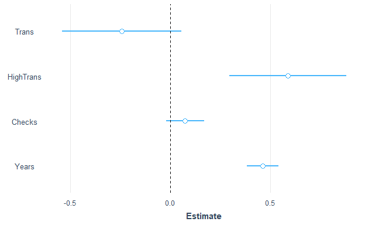

```r
plot_summs(reglin, scale = TRUE,
           plot.distributions = FALSE  )
```

## Collinearity

It is always a good habit to explore the correlation between the numerical variables in the data. This can give some insight to detect potential redundancies in the model.

In the case of a linear model, we’d like to avoid to have highly correlated regressors because

- redundant predictors add more complexity than information
- using highly correlated predictors result in unstable estimation and worse predictability

### Exploring Correlations

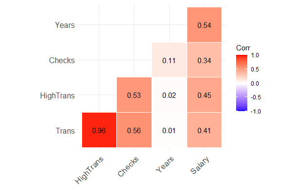

```r
library(ggcorrplot)
myvars <- BankAccount[,c("Trans", "HighTrans", "Checks", "Years", "Salary")]
# Compute a correlation matrix
corr_matrix<-cor(myvars)
# Visualize the lower triangle of the correlation matrix
ggcorrplot(corr_matrix, hc.order = FALSE, lab= "true",
                         type = "lower", outline.col = "white")
```

### Variance Inflation Factor

Is a measure of multicollinearity between variables. It indicates by how much the variance of the coefficient of $x_j$ is inflated due to the presence of other regressors. The VIF for regressor $x_j$ is calculated by - running a regression of $x_j$ on all other regressors - computing
$$VIF_j
= \frac{1}{1 - R^2_j}
\, .$$

- $VIF = 1$ indicates no collinearity
- A VIF larger than 10 (sometimes 5) is considered large

```r
summ(reglin,
     center = TRUE,
     scale = TRUE,
     vifs = TRUE)$coeftable %>%
  kable(digits=2) %>%
  kable_styling()
```

|  | Est. | S.E. | t val. | p | VIF |
| --- | --- | --- | --- | --- | --- |
| (Intercept) | 5.93 | 0.04 | 150.24 | 0.00 | NA |
| Trans | -0.24 | 0.15 | -1.60 | 0.11 | 14.71 |
| HighTrans | 0.59 | 0.15 | 3.94 | 0.00 | 14.15 |
| Checks | 0.07 | 0.05 | 1.53 | 0.13 | 1.47 |
| Years | 0.46 | 0.04 | 11.58 | 0.00 | 1.02 |

### Solutions to Multicollinearity

- Create new variables from the ones that are collinear, see e.g. Principal Components Analysis or Partial Least Squares (see the ISLR book for more on these).
- Take out some variables.

Let us try by removing the variable *Trans* from the model:

```r
# New linear regression model
reglin2 <- lm(Salary ~  HighTrans+ Checks + Years, data = BankAccount)

# Table
summ(reglin2, center = TRUE, scale = TRUE, vifs = TRUE)$coeftable %>%
  kable(digits=2) %>%
  kable_styling()
```

|  | Est. | S.E. | t val. | p | VIF |
| --- | --- | --- | --- | --- | --- |
| (Intercept) | 5.93 | 0.04 | 149.79 | 0.00 | NA |
| HighTrans | 0.36 | 0.05 | 7.69 | 0.00 | 1.40 |
| Checks | 0.06 | 0.05 | 1.24 | 0.22 | 1.41 |
| Years | 0.46 | 0.04 | 11.63 | 0.00 | 1.02 |

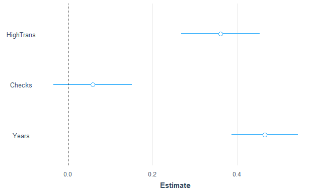

```r
plot_summs(reglin2, scale = TRUE)
```

In our example, omitting *Trans* (the Nb of transactions in 2020) does not change the fit of the model (adjusted $R^2$ was 0.482 and is now 0.479), nor the coefficients of the regressors not correlated with Trans. But the VIFs are now all small.

## Illustration on the complete model.

Let’s now look at the complete model and on the correlation between all variables

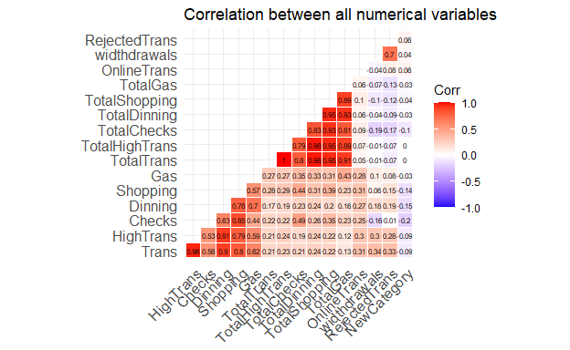

```r
# We compute the correlation matrix of all the numerical variables
corr_coef<-cor(BankAccount[,-c(7,14,15,19)],use = "p")
#And then plot it with nice options
ggcorrplot(corr_coef,
           type = "lower",         # lower triangle of the matrix only
           hc.order = FALSE,        # variable sorted from highest to lowest
           outline.col = "white",  #Color options
           lab = TRUE,
           lab_size = 2) +
  ggtitle("Correlation between all numerical variables")
```

> What can be said from this heatmap?

We can see that a lot of regressors are highly correlated, and so a selection of regressors is probably needed if one want our model to perform well. This is confirm when looking at the VIFs in the results of the regression on all variables.

```r
reglincomplete <- lm(Salary ~., data= BankAccount)
summ(reglincomplete, center = TRUE, scale = TRUE,
     vifs = TRUE)$coeftable %>%
  kable(digits=2) %>%
  kable_styling()
```

|  | Est. | S.E. | t val. | p | VIF |
| --- | --- | --- | --- | --- | --- |
| (Intercept) | 5.96 | 0.07 | 86.60 | 0.00 | NA |
| Trans | -0.44 | 0.18 | -2.42 | 0.02 | 22.94 |
| HighTrans | 0.59 | 0.21 | 2.83 | 0.01 | 30.28 |
| Checks | 0.10 | 0.11 | 0.98 | 0.33 | 7.76 |
| Dinning | -0.04 | 0.15 | -0.24 | 0.81 | 15.25 |
| Shopping | -0.04 | 0.13 | -0.33 | 0.74 | 11.92 |
| Gas | 0.24 | 0.08 | 3.08 | 0.00 | 4.15 |
| Years | 0.27 | 0.12 | 2.36 | 0.02 | 9.31 |
| TotalTrans | 0.29 | 0.60 | 0.49 | 0.63 | 251.56 |
| TotalHighTrans | -0.29 | 0.85 | -0.34 | 0.74 | 502.95 |
| TotalChecks | -0.01 | 0.26 | -0.02 | 0.98 | 46.49 |
| TotalDinning | 0.50 | 0.48 | 1.04 | 0.30 | 162.52 |
| TotalShopping | 0.04 | 0.44 | 0.10 | 0.92 | 131.97 |
| TotalGas | -0.39 | 0.17 | -2.30 | 0.02 | 19.74 |
| CategoryN | 0.28 | 0.15 | 1.83 | 0.07 | 4.13 |
| AgencyW | -0.17 | 0.08 | -2.11 | 0.04 | 1.08 |
| OnlineTrans | 0.09 | 0.04 | 2.25 | 0.03 | 1.24 |
| widthdrawals | 0.09 | 0.06 | 1.45 | 0.15 | 2.71 |
| RejectedTrans | -0.08 | 0.06 | -1.40 | 0.16 | 2.21 |
| NewCategory | -0.17 | 0.15 | -1.13 | 0.26 | 4.10 |

This is usually more difficult in practice.

> Which variables would you keep and which variables would you discard in the analysis?

# Selection of Regressors using Old (but Still Alive) Methods

It is a known fact in the Bank that there is nonlinearity of Salary with the number of years a household has spent in the bank, so we will add some polynomial terms in Years to our data frame. When doing this, it is good practice to center the variable before taking powers to avoid multicollinearity.

```r
meanYears <- mean(BankAccount$Years)
Years2 <- (BankAccount$Years - meanYears)^2
Years3 <- (BankAccount$Years - meanYears)^3
MyBankAccount <- data.frame(BankAccount, Years2, Years3)
```

## Stepwise Methods

Using the *leaps* package we can perform an automatic variable selection such as **forward selection**, **backward elimination**, or **exhaustive search** to find a better model. Here we will not use cross validation at first since stepwise regression has $2^k$ candidate models where $k$ is the number of explanatory variables. Meaning with 19 explanatory variables we have **524288** candidate models even without cross validating the results.

So we will first try to find the optimal number of variables to be used before cross validating the resulting model from the automatic variable selection. There are basically 3 traditional methods:

- Forward selection: starts with the constant term and adds one variable at a time, that yields the largest decrease in RSS (Residual Sum of Squares).[^2] Since the F statistic for a newly included variable is based on the relative decrease in RSS that the addition of a variable causes, the largest decrease in RSS is obtained for the variable whose inclusion yield the “most significant” F-test.
- Backward elimination: starts with the general model and eliminates one variable at a time, that yields the smallest decrease in RSS. Same kind comment here: smallest decrease in RSS is for the least significant variable.
- Stepwise selection, or Efroymsom’s procedure[^3]: forward selection, where at each step the possibility of deleting a variable as in backward elimination is considered, based on a t/F test.

Nothing unfortunately ensures that the “optimal” subset, or even the relevant variables, will be selected by mean of one of these methods. We also have the problem of multiple testing: if the probability of Type-I error is 5% for one test, when we do $m$ tests it can be up to $m$ times this probability (not accouting for the correlation between tests statistics).

We will use *caret* as a device to call functions in *leaps*. Caret main function is *train*. Here we use the extra argument *preProcess* to center and scale our regressors. To reduce the computational burden we restrict our choice to **8** variables in the final regression.

```r
nv <- 8
trctrl <- trainControl(method = "none")
leapF <- train(Salary ~., data = MyBankAccount,
               method = "leapForward",
               trControl = trctrl,
               preProcess = c("center","scale"),
               tuneGrid = expand.grid(nvmax = nv))

coef(leapF$finalModel,leapF$bestTune$nvmax) %>%
  kable(digits=2) %>%
  kable_styling()
```

|  | x |
| --- | --- |
| (Intercept) | 5.93 |
| Trans | -0.20 |
| HighTrans | 0.30 |
| TotalDinning | 0.46 |
| TotalShopping | 0.30 |
| CategoryN | 0.05 |
| OnlineTrans | 0.10 |
| Years2 | -0.72 |
| Years3 | 0.29 |

The result is the best model with 8 regressors obtained by forward selection. Note that it is not the same set that is obtained from backward selection.

```r
nv <- 8
trctrl <- trainControl(method = "none")
leapB <- train(Salary ~., data = MyBankAccount,
               method = "leapBackward",
               trControl = trctrl,
               preProcess = c("center","scale"),
               tuneGrid = expand.grid(nvmax = nv))

coef(leapB$finalModel,leapB$bestTune$nvmax) %>%
  kable(digits=2) %>%
  kable_styling()
```

|  | x |
| --- | --- |
| (Intercept) | 5.93 |
| Trans | -0.22 |
| HighTrans | 0.27 |
| Gas | 0.10 |
| TotalHighTrans | 0.48 |
| TotalShopping | 0.26 |
| OnlineTrans | 0.09 |
| Years2 | -0.71 |
| Years3 | 0.29 |

On this graphic, each horizontal row represent a model. One then have a visual summary of the variables used (black square) in various models and its impact on the adjusted $R^2$ (or other criterion, described later). The top row shows the variable used in the selected model.

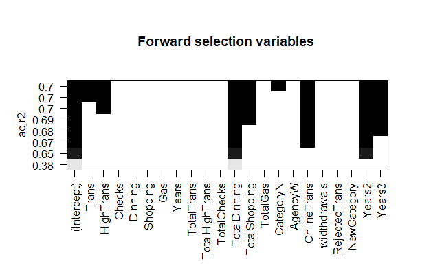

```r
regfit.fwd = regsubsets(Salary~.,
                        method = "forward",
                        data = MyBankAccount)


plot(regfit.fwd , scale ="adjr2",
     main = "Forward selection variables ",
     )
```

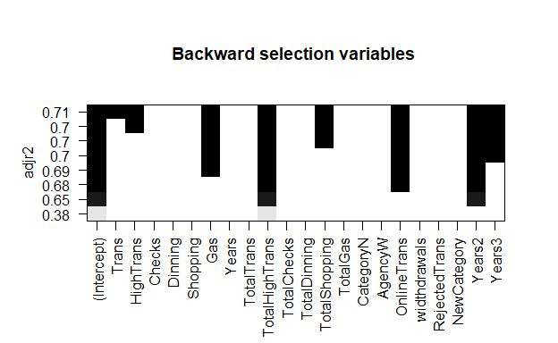

```r
regfit.bwd = regsubsets(Salary~.,
                        method = "backward",
                        data = MyBankAccount)

plot(regfit.bwd , scale ="adjr2",
     main = "Backward selection variables "
     )
```

## Criterions for finding the right number of variables

Let’s write the linear model in matrix form
$$y = X \beta + \varepsilon,$$
where

- $y$ is the $n\times 1$ vector of observations
- $X$ is the $n\times (k+1)$ matrix of rank $k+1$ containing regressors including the constant term
- $\varepsilon$ denote a general $n\times 1$ vector of i.i.d. errors with variance $\sigma^{2}$

Consider now a partition of $X$ in $X_p$ and $X_r$ with dimension $p+1$ ($p$ regressors plus the intercept) and $r$ $(=k-p-1)$ regressors respectively. We are looking for models of the general form
$$y = X_p \beta_p + \varepsilon
\, .$$
The dimension $p+1$ may vary along different approximating models, and there may also exists many approximating models with $p+1$ regressors from $k+1$, but we will use this generic form and called such a model a **p-model**.

Each p-model considers only $p+1$ regressors and is estimated by OLS and we thus obtain $\widehat {\beta}_p$. The reason for introducing this notation is to make explicit that we may consider in turn different sets of potential useful regressors.

> **We do not know exactly which p-model is true.**

### MSEP for Selecting Regressors

Based on a p-model, we will predict them $y_{new}$ by $X_p\widehat{\beta}_p$, so the *Mean Squared Error of Prediction* is
$$MSEP = n^{-1} E \| y_{new} - X_p\widehat{\beta}_p\|^2
\, ,$$
where the expectation is conditional on $X$.

**A bit of theory can help**

We can decompose MSEP as:
$$MSEP = n^{-1} \left\{ E \| y_{new} - X{\beta}\|^2
+
E \| X{\beta} - X_p\widehat{\beta}_p\|^2
\right\}
=
\sigma^2 +
n^{-1} E \| X{\beta} - X_p\widehat{\beta}_p\|^2
\, .$$
Indeed
$$E ( y_{new} - X{\beta})'
(X_p \widehat{\beta_p} - X\beta) =
E \, \varepsilon_{new}' \, (X_p \widehat{\beta_p} - X\beta)
= 0
\, ,$$
as $\varepsilon_{new}$ is independent of the original sample.

We can decompose the last term as
$$n^{-1}
\left\{
E \| X_p \widehat{\beta_p} - X_p\beta_p\|^2
+
E \| X_p {\beta_p} - X\beta\|^2
\right\}$$
where $\beta_p = E \widehat{\beta_p}$. This is because
$$E ( X_p \widehat{\beta_p} - X_p\beta_p)'
( X_p {\beta_p} - X\beta) = 0
\, .$$
The first term is a variance term, the second one a squared bias term. It is easy to see that

- $\widehat{\beta}_p=(X_p'X_p)^{-1}X_p'y$
- $X_p\beta_p = X_p E \widehat{\beta}_p = X_p (X_p'X_p)^{-1}X_p' X \beta = P_p X\beta$, where $P_p=X_p(X_p'X_p)^{-1}X_p'$ is the projection matrix on the subspace spanned by $X_p$.
- $X\beta-X_p\beta_p = M_p X\beta$, where $M_p = I -P_p$
- $X_p\widehat{\beta}_p - X_p\beta_p = P_p (y - X\beta) = P_p \varepsilon$.
- $E \|X_p\widehat{\beta}_p - X_p\beta_p\|^2 = E \ \varepsilon' P_p \varepsilon = \sigma^2 (p+1).$

Hence
$$MSEP = (1+(p+1)/n) \sigma^{2} + (1/n) \beta'X' M_p X\beta
\, .$$

### Mallows’ $C_p$ criterion

Mallows[^4] assumes that the complete model is correctly specified (still some of the coefficients may be zero). Under this assumption, the residual sum of squares for the complete model is such that
$$E(RSS_k)= E(y'M_k y) = (n-k-1) \sigma^{2}
\, .$$
The residual sum of squares for the p-model is such that
$$E(RSS_p)= E(y'M_p y) = {\beta}' X' M_p X\beta +
(n-p-1)\sigma^{2}
\, .$$
Hence
$$C_p = \frac{RSS_p}{n} + \frac{2(p+1)}{n} \frac{RSS_k}{n-k-1}$$
is an unbiased estimator for MSEP.

### Akaike Information Criterion ($AIC$)

One can show that the **Akaike information criterion (AIC)** for linear regression is
$$AIC \propto C_p
\, .$$
Since only the rankings of model is important, using AIC gives us the same raking than $C_p$.

### Bayesian Information Criterion ($BIC$)

$$BIC \propto \frac{RSS_p}{n} + \frac{(p+1) \log n}{n}
\frac{RSS_k}{n-k-1}$$
BIC penalizes large number of regressors more than AIC/$C_p$.

## Comparing the solutions

The library *leaps* allows an exhaustive search of all possible subsets of regressors (which should not take too long if you don’t have too many regressors!). We can then look for the best subset for different criterion.

### Solution proposed using $C_p$

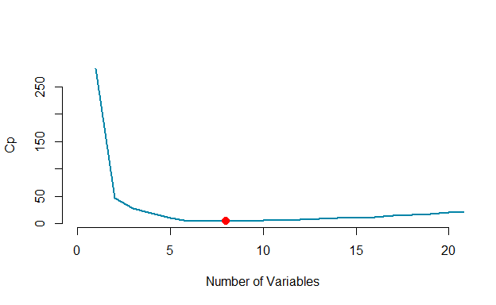

```r
regfit.full <- regsubsets(Salary~.,
                          data = MyBankAccount, nvmax = 21)
reg.summary <- summary(regfit.full)
# Look at names(reg.summary) to see which criterion are returned

plot(reg.summary$cp,
     xlab="Number of Variables",
     ylab="Cp",type='l', lwd=2,
     col = SIAP.color,
     xlim= c(0,20),
     frame.plot = FALSE)

# Adding minimum point
ind.Cp <- which.min(reg.summary$cp)
points(ind.Cp,reg.summary$cp[ind.Cp],col="red",cex=2,pch=20)
```

Using the $C_p$ criterion one would select only *8* regressors. You can look at the list of variables included in the model selected by $C_p$.

```r
xnames <- which(reg.summary$which[which.min(reg.summary$cp),])
f.Cp <- as.formula(paste("Salary","~",paste(names(xnames)[-1], collapse="+")))
# f.Cp
```

Here is what we obtain for the final $C_p$ model:

**Salary~Trans + Dinning + TotalHighTrans + TotalShopping + CategoryN + OnlineTrans + Years2 + Years3**

```r
names(xnames)[6] <- "Category"
f.Cp <- as.formula(paste("Salary","~",paste(names(xnames)[-1], collapse="+")))
reglin.Cp <- lm(f.Cp, data= MyBankAccount)
summ(reglin.Cp, center = TRUE, scale = TRUE,
     vifs = TRUE)$coeftable %>%
  kable(digits=2) %>%
  kable_styling()
```

|  | Est. | S.E. | t val. | p | VIF |
| --- | --- | --- | --- | --- | --- |
| (Intercept) | 5.89 | 0.04 | 142.19 | 0.00 | NA |
| Trans | -0.11 | 0.07 | -1.63 | 0.11 | 5.58 |
| Dinning | 0.23 | 0.07 | 3.25 | 0.00 | 5.50 |
| TotalHighTrans | 0.51 | 0.11 | 4.79 | 0.00 | 12.71 |
| TotalShopping | 0.27 | 0.10 | 2.80 | 0.01 | 10.42 |
| CategoryN | 0.09 | 0.06 | 1.43 | 0.15 | 1.07 |
| OnlineTrans | 0.10 | 0.03 | 3.18 | 0.00 | 1.14 |
| Years2 | -0.73 | 0.06 | -11.92 | 0.00 | 4.25 |
| Years3 | 0.29 | 0.07 | 3.94 | 0.00 | 6.09 |

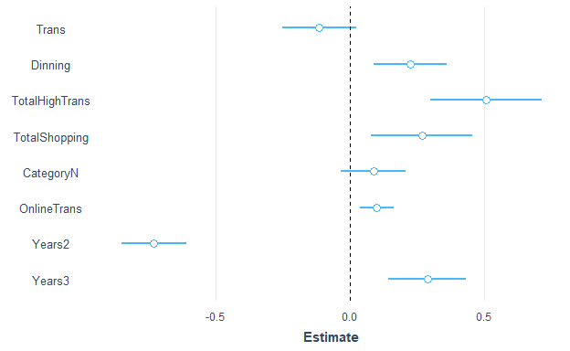

```r
plot_summs(reglin.Cp, scale = TRUE)
```

### Solution proposed using $BIC$

Here again, we can search and plot the BIC for different numbers of regressors

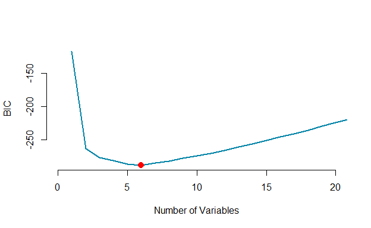

```r
plot(reg.summary$bic,
     xlab="Number of Variables",
     ylab="BIC",type='l', lwd=2,
     col = SIAP.color,
     xlim= c(0,20),
     frame.plot = FALSE)

# adding minimum point
ind.BIC <- which.min(reg.summary$bic)
points(ind.BIC,reg.summary$bic[ind.BIC],col="red",cex=2,pch=20)
```

```r
xnames.BIC <- which(reg.summary$which[which.min(reg.summary$bic),])
f.BIC <- as.formula(paste("Salary","~",paste(names(xnames.BIC)[-1], collapse="+")))
#f.BIC
```

**Salary~Dinning + TotalHighTrans + TotalShopping + OnlineTrans + Years2 + Years3**

```r
#names(xnames)[6] <- "Category"
f.BIC <- as.formula(paste("Salary","~",paste(names(xnames.BIC)[-1], collapse="+")))
reglin.BIC <- lm(f.BIC, data= MyBankAccount)
summ(reglin.BIC, center = TRUE, scale = TRUE,
     vifs = TRUE)$coeftable %>%
  kable(digits=2) %>%
  kable_styling()
```

|  | Est. | S.E. | t val. | p | VIF |
| --- | --- | --- | --- | --- | --- |
| (Intercept) | 5.93 | 0.03 | 199.17 | 0.00 | NA |
| Dinning | 0.12 | 0.03 | 3.44 | 0.00 | 1.31 |
| TotalHighTrans | 0.50 | 0.10 | 4.74 | 0.00 | 12.38 |
| TotalShopping | 0.27 | 0.10 | 2.81 | 0.01 | 10.28 |
| OnlineTrans | 0.10 | 0.03 | 3.11 | 0.00 | 1.10 |
| Years2 | -0.73 | 0.06 | -11.83 | 0.00 | 4.23 |
| Years3 | 0.29 | 0.07 | 3.93 | 0.00 | 6.08 |

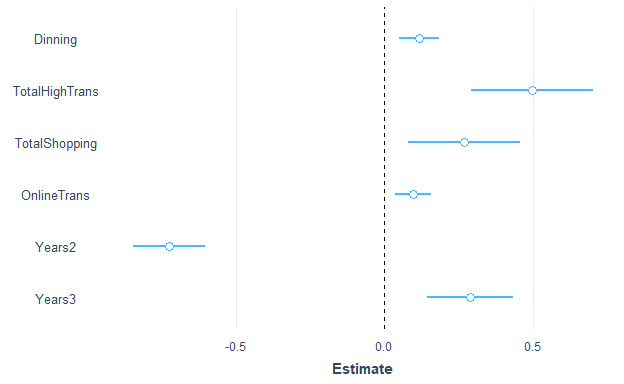

```r
plot_summs(reglin.BIC, scale = TRUE)
```

## Cross Validation

In practice, we can apply any cross validation methods we know to estimate MSEP and select the “best” model.

```r
library(parallel)
library(doParallel)
```

#### Benchmarking

Cross-validation can be used to evaluate the “fit” of a single model. This is useful to know whether our more elaborate methods yield some improvements.

For instance, we can evaluate the MSEP for the linear model that includes all regressors using cross-validation.

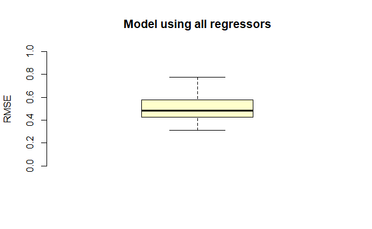

```r
# control variables
numbers <- 5
repeats <- 20
rcvTunes <- 1 # tune number of models
seed <- 123
# repeated cross validation
rcvSeeds <- setSeeds(method = "repeatedcv",
                     numbers = numbers, repeats = repeats,
                     tunes = rcvTunes, seed = seed)

nrcore <- 5
cl <- makeCluster(mc <- getOption("cl.cores", nrcore))
registerDoParallel(cl)

# Train control
rcvControl <- trainControl(method = "repeatedcv",
                        number = numbers, repeats = repeats,
                        seeds = rcvSeeds)
set.seed(123)
lm <- train(Salary ~., data = MyBankAccount,
               method = "lm",
               trControl = rcvControl,
               preProcess = c("center","scale"))
stopCluster(cl)
boxplot(lm$resample$RMSE, main="Model using all regressors",
        ylab = "RMSE",
        col='#ffffcc',ylim = range(0:1),  frame.plot = FALSE)
```

Alternatively, we could look at the performances of the model selected by $C_p$.

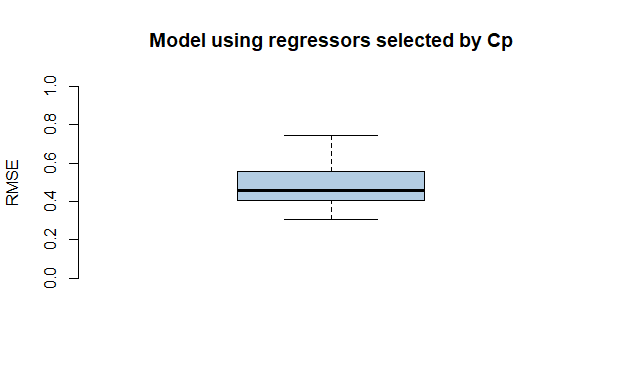

```r
nrcore <- 5
cl <- makeCluster(mc <- getOption("cl.cores", nrcore))
registerDoParallel(cl)

set.seed(123)
lmcp <- train(f.Cp, data = MyBankAccount, method = "lm",
            trControl = rcvControl,
            preProcess = c("center","scale"))
stopCluster(cl)
boxplot(lmcp$resample$RMSE,
        main= "Model using regressors selected by Cp",
        ylab = "RMSE",
        col='#b3cde3',ylim = range(0:1),  frame.plot = FALSE)
```

And the model selected by $BIC$.

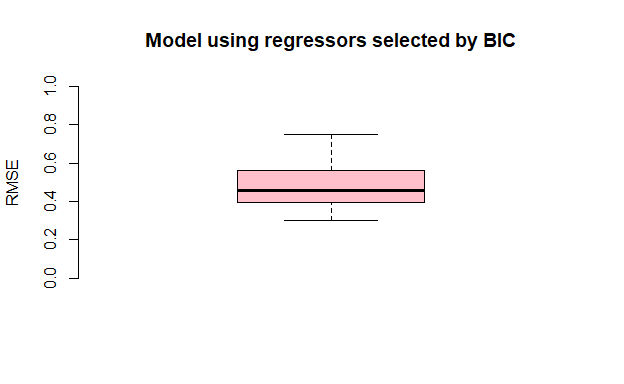

```r
nrcore <- 5
cl <- makeCluster(mc <- getOption("cl.cores", nrcore))
registerDoParallel(cl)

set.seed(123)
lmBIC <- train(f.BIC, data = MyBankAccount, method = "lm",
            trControl = rcvControl,
            preProcess = c("center","scale"))
stopCluster(cl)
boxplot(lmBIC$resample$RMSE,
        main= "Model using regressors selected by BIC",
        ylab = "RMSE",
        col='pink',ylim = range(0:1),  frame.plot = FALSE)
```

#### Forward Selection

Here we will use CV to select the number of variables in the model.

```r
# control variables
numbers <- 5
repeats <- 20
rcvTunes <- 12 # tune number of models
seed <- 123
# repeated cross validation
rcvSeeds <- setSeeds(method = "repeatedcv",
                     numbers = numbers, repeats = repeats,
                     tunes = rcvTunes, seed = seed)

# Train control
rcvControl <- trainControl(method = "repeatedcv",
                        number = numbers, repeats = repeats,
                        seeds = rcvSeeds)
nrcore <- 5
cl <- makeCluster(mc <- getOption("cl.cores", nrcore))
registerDoParallel(cl)

set.seed(123)
leapF <- train(Salary ~., data = MyBankAccount,
               method = "leapForward",
               trControl = rcvControl,
               preProcess = c("center","scale"),
               tuneGrid = expand.grid(nvmax = 1:12))
stopCluster(cl)
```

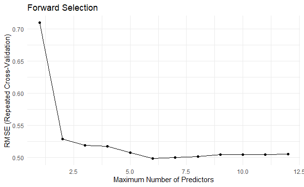

```r
ggplot(leapF)+
  ggtitle("Forward Selection") +
  theme_minimal()
```

```r
#Regression results
coef(leapF$finalModel,leapF$bestTune$nvmax) %>%
  kable(digits=2) %>%
  kable_styling()
```

|  | x |
| --- | --- |
| (Intercept) | 5.93 |
| HighTrans | 0.10 |
| TotalDinning | 0.47 |
| TotalShopping | 0.30 |
| OnlineTrans | 0.10 |
| Years2 | -0.73 |
| Years3 | 0.30 |